# Comparison of McGrath Videolaryngoscopy and Direct Laryngoscopy for Rapid Sequence Intubation: an international, multicenter randomized trial

Will Patterson

2024-04-11

## Study overview

This analysis was conducted with data from 394 patients who were randomized to either videolaryngoscopy (n = 193) or direct laryngoscopy (201). The primary outcome of interest is the visualization of the vocal cords, as measured by the Cormack and Lehane classification.

|  | Direct laryngoscopy (N=201) | McGrath videolaryngoscope (N=193) | Overall (N=394) |
| --- | --- | --- | --- |
| Age (years) |  |  |  |
| Median [Q1, Q3] | 46.0 [37.0, 57.0] | 46.0 [35.0, 56.0] | 46.0 [36.3, 57.0] |
| Mobility of the cervical spine (degrees) (degrees) |  |  |  |
| 45 | 122 (60.7%) | 110 (57.0%) | 232 (58.9%) |
| 30 | 55 (27.4%) | 64 (33.2%) | 119 (30.2%) |
| 15 | 19 (9.5%) | 18 (9.3%) | 37 (9.4%) |
| 0 | 0 (0%) | 0 (0%) | 0 (0%) |
| Mouth opening (cm) |  |  |  |
| Mean (SD) | 4.86 (1.21) | 4.71 (1.21) | 4.79 (1.21) |
| Inter-incisor gap (cm) |  |  |  |
| Mean (SD) | 4.13 (1.11) | 4.06 (0.939) | 4.10 (1.03) |
| Thyromental distance (cm) |  |  |  |
| Mean (SD) | 7.74 (1.48) | 7.90 (1.70) | 7.82 (1.59) |
| Sternomental distance (cm) |  |  |  |
| Mean (SD) | 14.8 (2.52) | 14.9 (2.57) | 14.8 (2.54) |
| Upper lip bite test class |  |  |  |
| I | 108 (53.7%) | 115 (59.6%) | 223 (56.6%) |
| II | 83 (41.3%) | 67 (34.7%) | 150 (38.1%) |
| III | 6 (3.0%) | 10 (5.2%) | 16 (4.1%) |
| Mallampati score |  |  |  |
| I | 54 (26.9%) | 59 (30.6%) | 113 (28.7%) |
| II | 104 (51.7%) | 89 (46.1%) | 193 (49.0%) |
| III | 35 (17.4%) | 39 (20.2%) | 74 (18.8%) |
| IV | 3 (1.5%) | 5 (2.6%) | 8 (2.0%) |
| Teeth status |  |  |  |
| No missing teeth | 132 (65.7%) | 141 (73.1%) | 273 (69.3%) |
| Edentulous | 17 (8.5%) | 12 (6.2%) | 29 (7.4%) |
| Missing frontal teeth | 17 (8.5%) | 10 (5.2%) | 27 (6.9%) |
| Full denture | 31 (15.4%) | 29 (15.0%) | 60 (15.2%) |
| Mandibular protrusion test |  |  |  |
| A | 106 (52.7%) | 113 (58.5%) | 219 (55.6%) |
| B | 76 (37.8%) | 64 (33.2%) | 140 (35.5%) |
| C | 15 (7.5%) | 15 (7.8%) | 30 (7.6%) |
| Neck circumference (cm) |  |  |  |
| Median [Q1, Q3] | 39.0 [37.4, 41.0] | 39.0 [36.8, 42.0] | 39.0 [37.0, 42.0] |

### Addressing data imbalance by group randomization

From the above table, it appears the randomized groups differ by a few characteristics that were determined *a priori* to be potential confounders. To quantify the difference, we calculate the absolute standardized difference that tells us the observed magnitude of difference.

$$ASD=\frac{100\times|\hat{p}_{video}-\hat{p}_{direct}|}{\sqrt{\frac{\hat{p}_{video}(1-\hat{p}_{video})+\hat{p}_{direct}(1-\hat{p}_{direct})}{2}}}$$
These values are shown in the table below.

```r
stddiffs <- calculate_stddiff(data, randomized_to) %>% rownames_to_column("name")
stddiffs %>%
  arrange(desc(stddiff)) %>%
  filter(name %in% adj_vars) %>%
  mutate(adj_0.1 = stddiff >= 0.1) %>%
  select(name, stddiff, adj_0.1) %>%
  kbl(caption = "Standardized mean differences for potential confounders",
    booktabs = T,
    escape = F,
    col.names = c("Covariate", "ASD", "Adjust? (0.1)")) %>%
  kable_classic(full_width = FALSE, position = "center",
                            html_font = "Cambria")
```

Standardized mean differences for potential confounders

| Covariate | ASD | Adjust? (0.1) |
| --- | --- | --- |
| teeth_status | 0.176 | TRUE |
| upper_lip_bite_test_class | 0.172 | TRUE |
| mallampati_score | 0.146 | TRUE |
| gender | 0.145 | TRUE |
| difficult_airway_hx_yn | 0.145 | TRUE |
| mouth_opening_cm | 0.124 | TRUE |
| bmi | 0.123 | TRUE |
| thyromental_height_cm | 0.122 | TRUE |
| mobility_cervical_spine | 0.115 | TRUE |
| mandibular_protrusion_test | 0.111 | TRUE |
| thyromental_distance_cm | 0.101 | TRUE |
| height_cm | 0.095 | FALSE |
| neck_circumference_cm | 0.083 | FALSE |
| inter_incisor_gap_cm | 0.075 | FALSE |
| asa_class | 0.069 | FALSE |
| sternomental_distance_cm | 0.068 | FALSE |
| cpap_use_yn | 0.061 | FALSE |
| weight_kg | 0.051 | FALSE |
| osa_yn | 0.022 | FALSE |
| age | 0.016 | FALSE |
| snoring_yn | 0.003 | FALSE |

Values with an ASD of 0.1 or greater (i.e., Adjust? column is `TRUE`) are considered to be imbalanced between the two groups. We will adjust for these variables in the analysis.

## Primary hypothesis: Visualization

**Videolaryngoscopy improves visualization of the vocal cords, defined using the modified Cormack and Lehane classification (primary outcome), versus direct laryngoscopy.**

### Distribution of Cormack and Lehane scores

First, we examine the distribution of Cormack and Lehane (CL) scores by randomization group. A lower CL score indicates a better visualization (e.g., a score of 1 indicates full view of the glottis).

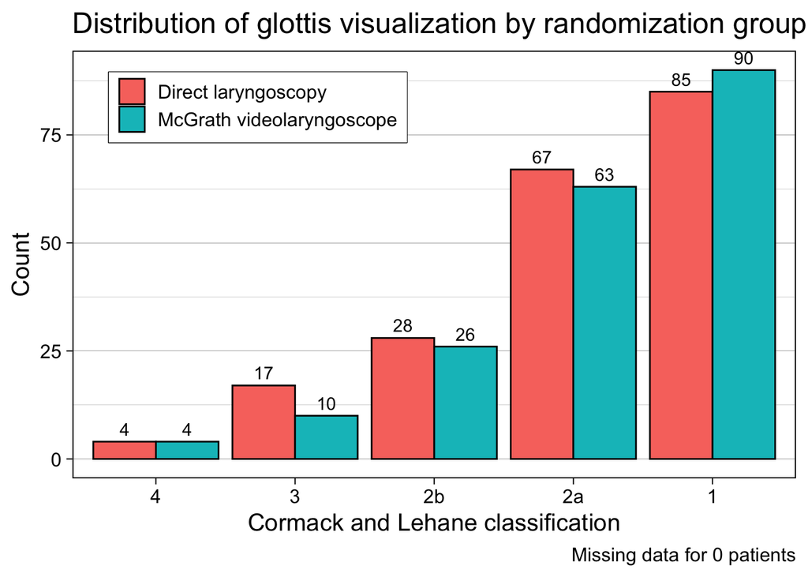

Here, it appears that the distribution of CL scores is similar between the two randomization groups. Indeed, the median CL score is the same for both groups (2a). We can test whether the distribution of these scores is different by randomization status two ways: crude analysis (Wilcoxon-Mann-Whitney test) and adjusted analysis (proportional odds logistic regression model).

### Crude analysis: Wilcoxon-Mann-Whitney

We used the Wilcoxon-Mann-Whitney test to formally compare categorical outcome of glottis visualization (Cormack and Lehane classification) at the 5% significance level between the two study groups. This test does not account for any potential confounding variables.

```r
# Wilcoxon-Mann-Whitney test
(ph1_wmw <- data %>%
  filter(!is.na(cl_grade)) %>%
  mutate(cl_grade = as.numeric(cl_grade)) %>%
  rstatix::wilcox_test(cl_grade ~ randomized_to, data = .))
```

```
## # A tibble: 1 × 7
##   .y.      group1              group2                   n1    n2 statistic     p
## * <chr>    <chr>               <chr>                 <int> <int>     <dbl> <dbl>
## 1 cl_grade Direct laryngoscopy McGrath videolaryngo…   201   193    18288. 0.294
```

The Wilcoxon-Mann-Whitney test does not suggest that there is a significant difference in the distribution of CL scores between the two randomization groups (p = 0.29).

### Adjusted analysis: proportion odds logistic regression model

```r
(fit1 <- glm.fit.saturated %>%
  tbl_regression(exponentiate = TRUE) %>%
  add_global_p()  %>%
  modify_caption("Proportional odds logistic regression for CL grade"))
```

Proportional odds logistic regression for CL grade

| **Characteristic** | **OR**<sup>1</sup> | **95% CI**<sup>1</sup> | **p-value** |
| --- | --- | --- | --- |
| randomized_to |  |  | 0.6 |
| Direct laryngoscopy | — | — |  |
| McGrath videolaryngoscope | 1.12 | 0.76, 1.66 |  |
| teeth_status |  |  | 0.029 |
| No missing teeth | — | — |  |
| Edentulous | 2.77 | 1.24, 6.54 |  |
| Missing frontal teeth | 0.65 | 0.31, 1.36 |  |
| Full denture | 1.33 | 0.75, 2.38 |  |
| upper_lip_bite_test_class |  |  | 0.9 |
| I | — | — |  |
| II | 0.94 | 0.59, 1.50 |  |
| III | 1.27 | 0.42, 4.05 |  |
| mallampati_score |  |  | <0.001 |
| I | — | — |  |
| II | 0.53 | 0.32, 0.86 |  |
| III | 0.35 | 0.19, 0.64 |  |
| IV | 0.08 | 0.02, 0.40 |  |
| gender |  |  | 0.14 |
| Female | — | — |  |
| Male | 0.72 | 0.47, 1.11 |  |
| Mouth opening | 0.91 | 0.74, 1.12 | 0.4 |
| BMI | 0.97 | 0.93, 1.01 | 0.14 |
| Thyromental height | 0.91 | 0.78, 1.05 | 0.2 |
| Thyromental distance | 1.21 | 1.05, 1.40 | 0.009 |
| mandibular_protrusion_test |  |  | 0.3 |
| A | — | — |  |
| B | 0.71 | 0.42, 1.21 |  |
| C | 0.56 | 0.24, 1.30 |  |
| mobility_cervical_spine |  |  | 0.9 |
| 45 | — | — |  |
| 30 | 0.89 | 0.54, 1.45 |  |
| 15 | 0.98 | 0.47, 2.06 |  |

<sup>1</sup> OR = Odds Ratio, CI = Confidence Interval

The proportional odds logistic regression model does not support an improvement in glottis visualization (as measured by CL score) with randomization to the videolaryngoscopy group (OR = 1.12, 95% CI 0.76-1.66, p = 0.56).

Results from the crude and adjusted analysis of the primary hypothesis align: this study does not provide evidence that videolaryngoscopy improves visualization of the vocal cords compared to direct laryngoscopy.

## Secondary hypothesis: Intubation attempts/failures

**McGrath videolaryngoscopy decreases number of intubation attempts and the number of intubation failures compared to direct laryngoscopy.**

### Intubation attempts

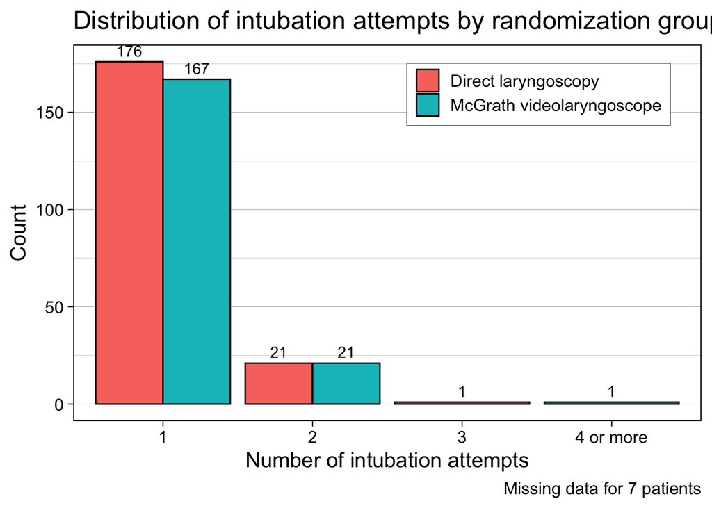

Again, the distribution of intubation attempts seems similar between the groups. We are missing data for 7 patients (3 in the direct laryngoscopy group and 4 in the videolaryngoscopy group).

```r
data %>%
  tabyl(randomized_to, intubation_attempts) %>%
  adorn_title()
```

```
##                            intubation_attempts
##              randomized_to                   1  2 3 4 or more NA_
##        Direct laryngoscopy                 176 21 1         0   3
##  McGrath videolaryngoscope                 167 21 0         1   4
```

```r
# Wilcoxon-Mann-Whitney test (crude analysis)
(sh1_wmw <- data %>%
  filter(!is.na(intubation_attempts)) %>%
  mutate(intubation_attempts = as.numeric(intubation_attempts)) %>%
  rstatix::wilcox_test(intubation_attempts ~ randomized_to, data = .))
```

```
## # A tibble: 1 × 7
##   .y.                 group1              group2        n1    n2 statistic     p
## * <chr>               <chr>               <chr>      <int> <int>     <dbl> <dbl>
## 1 intubation_attempts Direct laryngoscopy McGrath v…   198   189    18612.  0.87
```

There was not evidence to support the hypothesis that the number of intubation attempts differed between the two randomization groups (p = 0.87).

```r
fit2 %>%
  tbl_regression(exponentiate = TRUE) %>%
  add_global_p()
```

| **Characteristic** | **IRR**<sup>1</sup> | **95% CI**<sup>1</sup> | **p-value** |
| --- | --- | --- | --- |
| randomized_to |  |  | 0.5 |
| Direct laryngoscopy | — | — |  |
| McGrath videolaryngoscope | 1.21 | 0.66, 2.25 |  |
| teeth_status |  |  | 0.5 |
| No missing teeth | — | — |  |
| Edentulous | 1.01 | 0.24, 2.91 |  |
| Missing frontal teeth | 1.50 | 0.54, 3.58 |  |
| Full denture | 0.49 | 0.11, 1.45 |  |
| upper_lip_bite_test_class |  |  | 0.006 |
| I | — | — |  |
| II | 3.08 | 1.51, 6.56 |  |
| III | 1.44 | 0.20, 6.45 |  |
| mallampati_score |  |  | 0.012 |
| I | — | — |  |
| II | 3.45 | 1.30, 11.9 |  |
| III | 5.64 | 1.93, 20.6 |  |
| IV | 3.56 | 0.46, 20.2 |  |
| gender |  |  | 0.029 |
| Female | — | — |  |
| Male | 2.07 | 1.08, 4.06 |  |
| Mouth opening | 0.97 | 0.70, 1.34 | 0.9 |
| BMI | 0.96 | 0.89, 1.02 | 0.2 |
| Thyromental height | 0.83 | 0.65, 1.05 | 0.12 |
| Thyromental distance | 0.99 | 0.80, 1.23 | >0.9 |
| mandibular_protrusion_test |  |  | 0.7 |
| A | — | — |  |
| B | 1.02 | 0.47, 2.22 |  |
| C | 1.58 | 0.51, 4.43 |  |
| mobility_cervical_spine |  |  | 0.3 |
| 45 | — | — |  |
| 30 | 1.11 | 0.55, 2.24 |  |
| 15 | 0.43 | 0.09, 1.47 |  |

<sup>1</sup> IRR = Incidence Rate Ratio, CI = Confidence Interval

Similar to our crude analysis, the adjusted analysis does not support the hypothesis that the number of intubation attempts differed between the two randomization groups.

### Intubation failures

There were 4 intubation failures in the study, three from the McGrath videolaryngoscope and one from the direct laryngoscope.

```r
(intub_fail <- data %>%
  mutate(intub_success = ifelse(intubation_result == "Intubation successful", TRUE, FALSE)) %>%
  select(intub_success, randomized_to) %>%
  table())
```

```
##              randomized_to
## intub_success Direct laryngoscopy McGrath videolaryngoscope
##         FALSE                   1                         3
##         TRUE                  200                       190
```

#### Crude analysis: Chi-squared test

```r
(intub_fail_test <- intub_fail %>%
  rstatix::chisq_test(intub_success ~ randomized_to))
```

```
## # A tibble: 1 × 6
##       n statistic     p    df method          p.signif
## * <int>     <dbl> <dbl> <int> <chr>           <chr>
## 1   394     0.295 0.587     1 Chi-square test ns
```

The chi-squared test does not support the hypothesis that the number of intubation failures differed between the two randomization groups (p = 0.59).

## Safety outcomes

Safety outcomes were analysed by study groups without formal statistical testing of the difference. Safety was assessed by four outcomes:

1. Incidence of cut lips, airway injury, or dental injury;
2. Incidence of postoperative coughing;
3. Incidence or severity of postoperative sore throat;
4. Incidence or severity of postoperative hoarseness.

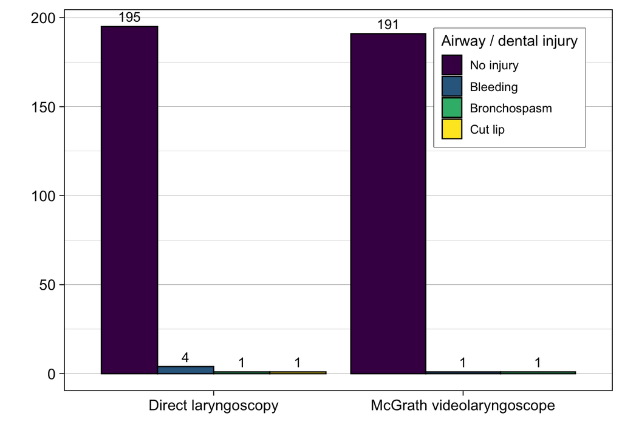

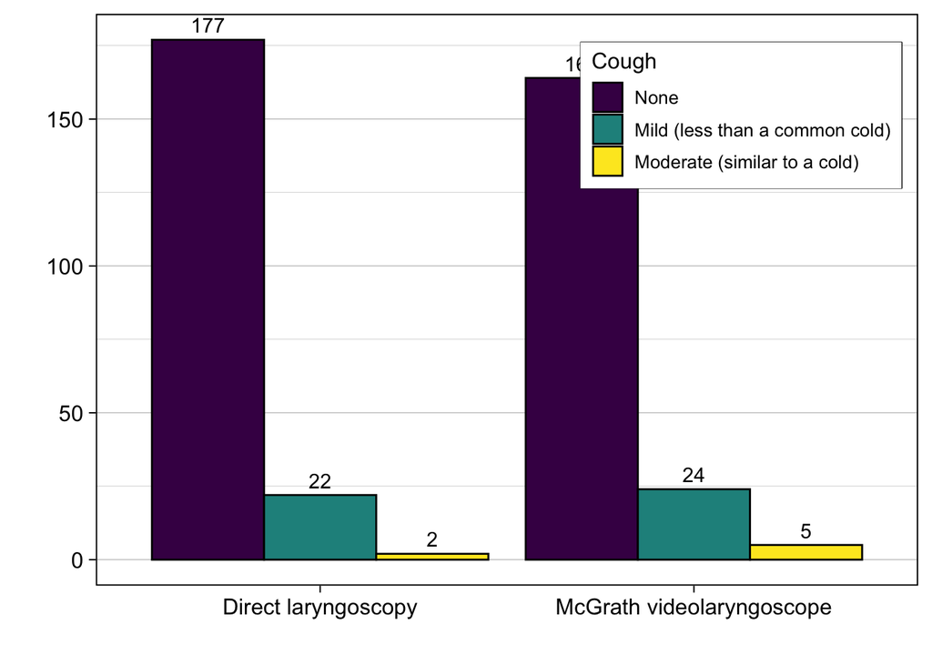

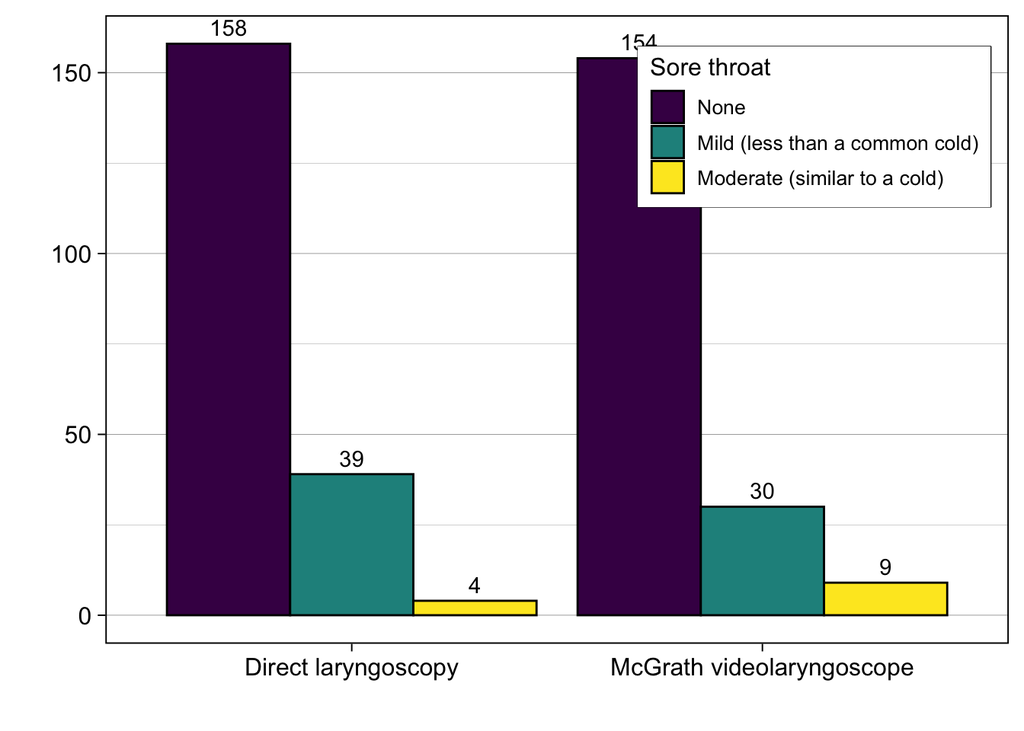

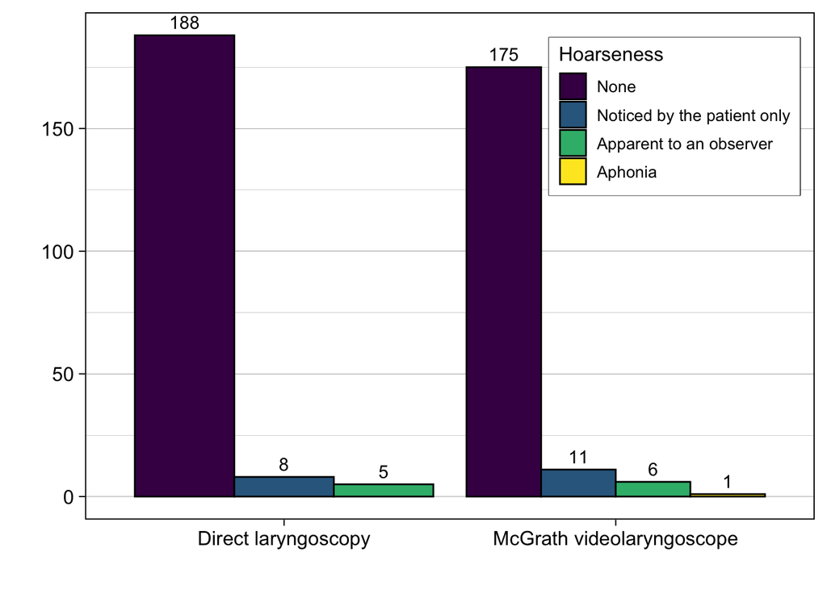

The incidence of all safety outcomes was similar across groups.